# Application of Newton's Laws of Motion

### Free body diagrams

**Free-body diagrams** are used to represent all the forces on an object to determine the net force on it. They are termed free-body diagrams because each diagram considers only the forces acting on the particular object considered.

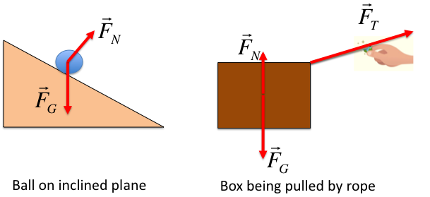

### Lifting an Object

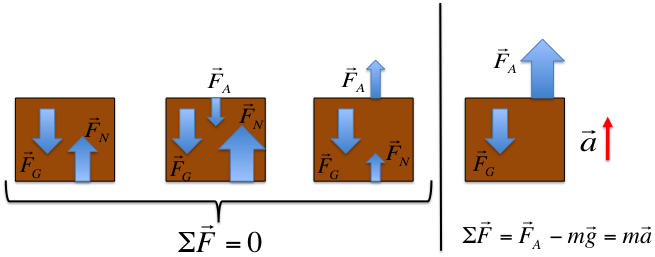

$\vec{F}_N=-m\vec{g}-\vec{F}_A$

Note that $\vec{F}_N$ is **always** $\ge0$

### Dragging an object (on ice)

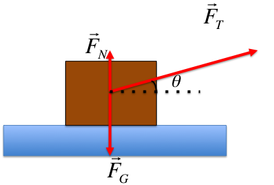

$\sum\vec{F}_x = F_T cos\theta \hat{i}$

$\sum\vec{F}_y = F_T sin\theta \hat{j}+ \vec{F}_G+ \vec{F}_N$

### Forces on Inclined Planes

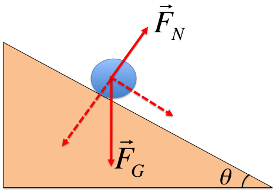

$\sum\vec{F}_{\parallel} = F_G sin\theta \hat{i}=mgsin\theta \hat{i}$

$\sum\vec{F}_{\perp} = F_G cos\theta \hat{j}+ \vec{F}_N$

### Atwood's Machine

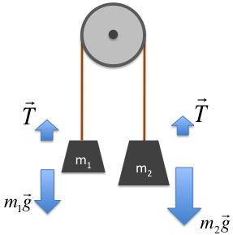

For this system ([Atwood's Machine](https://en.wikipedia.org/wiki/Atwood_machine)) we need to consider free-body diagrams for two objects. $\vec{a}$ is the same in magnitude for each weight, the sign relative to gravity must be opposite on one side from another. The weights are both connected by the same rope and thus the force due to tension is the same for each object. The concept behind this device is used in elevators and [funiculars](https://en.wikipedia.org/wiki/Funicular)

$\large m_{1}\vec{a}=\vec{T}-m_{1}\vec{g}$ $\large m_{2}\vec{a}=m_{2}\vec{g}-\vec{T}$

$\large \vec{T}=m_{1}\vec{a}+m_{1}\vec{g}$ $\large \vec{T}=m_{2}\vec{g}-m_{2}\vec{a}$

$\large m_{1}\vec{g}+m_{1}\vec{a}=m_{2}\vec{g}-m_{2}\vec{a}$

$\large (m_{1}+m_{2})\vec{a}=(m_{2}-m_{1})\vec{g}$

$\large \vec{a}=\vec{g}\frac{m_{2}-m_{1}}{m_{2}+m_{1}}$

$\large \vec{T}=\vec{g}\frac{2m_{2}m_{1}}{m_{2}+m_{1}}$

### More pulleys

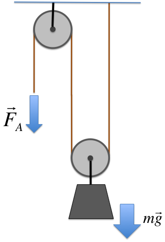

### More pulleys solved

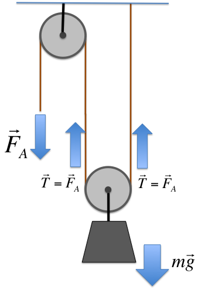

### Pendulum style accelerometer

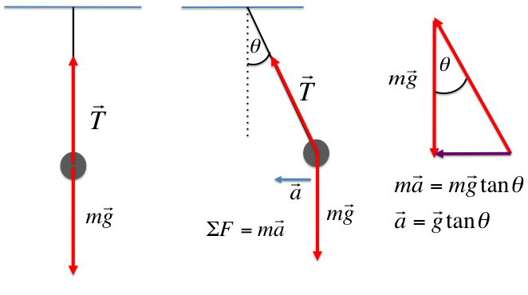

### How does a boat sail upwind?

[Skilled sailors](https://www.youtube.com/watch?v=YxRgaJJ86_8) can sail at a broad range of angles to the wind and with [modern boats](https://www.youtube.com/watch?v=wbJBk7MlG0k) it is possible to go substantially faster than the windspeed.

Sailing a boat close to the wind is in fact a very neat physics trick. A very nice explanation is [here](http://www.phys.unsw.edu.au/~jw/sailing.html).

A simplified version:

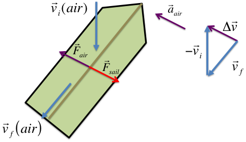

Note that to balance the sideways force a boat requires some lateral resistance from the water and the correct positioning of the weight of the crew.

### Connecting Newton's Laws to kinematics

Finding the net force on an object allows us to determine it's acceleration, which from which we can, given supplementary information, deduce the motion of an object.

$\large v= v_{0}+at$

$\large x= x_{0}+v_{0}t+\frac{1}{2}at^2$

$\large v^{2}=v_{0}^2+2a(x-x_{0})$

or

$\large \vec{v}(t)=\vec{v}_{0}+\int^{t}_{0}\vec{a}(t)\,dt$

$\large \vec{x}(t)=\vec{x}_{0}+\int^{t}_{0}\vec{v}(t)\,dt$

### Missing in this picture

- frictional forces
- air resistance

Covered in the next lecture